# S1.4c — BL-098 riformulata: forma del nucleo nei tessuti densi (scala contro ritaglio)

geo_spatialtrans — report di step

Published

October 16, 2026

**Obiettivo unico**: decidere il modello di forma del nucleo nei tessuti densi — **scalare** (K-c, pacchetto attuale, D-S1.4.2) contro **ritagliare nel territorio** (K-1, K-2) — sui 30 tassellamenti primari di S1.4, parametri M2 e semi di S1.4, misurando reali e simulati con **lo stesso operatore** (nuclei simulati rasterizzati sulla griglia nativa del ROI). Prototipo in `tools/`; `R/04b3*`, `R/04b4*` non modificati (implementazione in S1.4d).

| Variante | Centro | Forma |
| --- | --- | --- |
| **K-c** | POI | 32-gono di area M2, scala ridotta dal clamp 0.85 (= V-c di S1.4b) |
| **K-1** | generatore | 32-gono di area M2 ∩ territorio di Voronoi (solo ritaglio) |
| **K-2** | generatore | come K-1, raggio aumentato finché l’area ritagliata = target; tetto φ·A_T, φ = min(1, q99 di N/C dei ROI di addestramento) |

# 1. Pre-registrazione

Testo integrale: `results/S1.4c/S1.4c_preregistration.md` (commit `c41cf8b`), approvato da Luca il 2026-10-15 («vai»), dopo le scelte «Banco + decisione; implementazione in 04b4 nella sessione dopo» e «K-c, K-1, K-2 nel Voronoi». Definizioni operative e difetti di sviluppo: `results/S1.4c/S1.4c_dev_notes.md` (commit `e76cb6d`, prima degli stadi ufficiali, con il codice di analisi e decisione e i loro test — BL-090 d).

| Check | Attesa | Soglia | Fonte |
| --- | --- | --- | --- |
| C-0 | K-c = V-c di S1.4b | identico | S1.4b |
| C3 / C-NO / C-area | K-1, K-2 nel territorio; disgiunti; K-2 area = target | 0 / 0 / ≤ 1e-6 | design §7.2 |
| C-R | operatore raster su casi analitici | dev notes | — |
| C-mut | 5 mutanti | 5/5 | prassi |
| C-perf | K-2 su 449 536 celle | ≤ 300 s, ≤ 8 GB (solo WARN) | design §6.2 |
| B-1, B-2 | KS di N/C e A_N | metro inter-ROI, mediana di 10 semi | S1.4 |
| B-7, B-8 | cerchio di pari area fuori dal Voronoi dei centroidi; cerchi sovrapposti | metro inter-ROI | S1.4 PH-1, S1.4b |
| S-1, S-2, S-3 | nuclei a contatto (2 px); perimetro a contatto; solidità | metro inter-ROI | nuove |
| B-4 | frazione troncata | ≤ 5 % (fuori dal punteggio) | ROADMAP §4 |
| CP-0 | sovrapposizione dei cerchi predice il contatto reale | AUC ≥ 0.75 in ≥ 3 di A1–A4 | convenzione |
| CP-1 | guadagno K-2 su K-c specifico dei tessuti densi | guadagno A5+A6 < guadagno per coppia A1–A4 | — |
| CP-2 | riferimenti di forma robusti al segmentatore | altrimenti metrica S descrittiva | — |
| Regola | punteggio ≥ K-c + 3 e P(bootstrap) ≥ 0.9; parità → la più semplice | — | convenzioni senza fonte |

**Difetti trovati in sviluppo** (prima del run, dev notes D-1…D-5): ritaglio sulla griglia F1 (C3 36/~1 000 → territorio rientrato di 1e-5 µm), buffer negativo con modello di precisione che restituisce poligoni vuoti in silenzio (23/674), sentinella dell’operatore raster (contatti spuri), tolleranza di K-2, mutante MU2 con n = 1. **Difetti trovati dopo il run, nel codice di analisi** (D-6, D-7): (D-6) K-2 risultava non eleggibile perché il filtro dell’eleggibilità includeva la riga di C-perf (WARN), contro il testo «C-perf solo WARN»; la prima analisi riportava quindi «scelta: K-1». Corretto, la scelta per regola è **K-2**. (D-7) AUC di CP-0 in A4 = NA per overflow di interi; corretto (0.974). Entrambe le correzioni sono dichiarate; la tabella prima della correzione è conservata.

# 2. Check C — correttezza software

```r
tb(ck[, c("check", "what", "value", "threshold", "verdict")])
```

| check | what | value | threshold | verdict |
| --- | --- | --- | --- | --- |
| C-0 | K-c = V-c di S1.4b (fold x semi 0..10) | 330/330 | tutti identici | PASS |
| C3 | K-1 nucleo dentro il territorio (geos \| sf) | 0 \| 0 | 0 \| 0 | PASS |
| C-NO | K-1 coppie sovrapposte (> 1e-9 µm²); max area | 0; 0.00e+00 | 0 | PASS |
| C-empty | K-1 nuclei vuoti | 0 | 0 | PASS |
| C3 | K-2 nucleo dentro il territorio (geos \| sf) | 0 \| 0 | 0 \| 0 | PASS |
| C-NO | K-2 coppie sovrapposte (> 1e-9 µm²); max area | 0; 0.00e+00 | 0 | PASS |
| C-empty | K-2 nuclei vuoti | 0 | 0 | PASS |
| C-area | K-2 max \|A - A*\| / A* senza tetto | 5.84e-07 | <= 1e-6 | PASS |
| C-OP | reali: appaiamento e aree identici a S1.4 (30 ROI) | 30/30, 30/30 | 30/30 | PASS |
| C-OP | reali: territori osservati = S1.4 (max rel A_T; max \|d\|) | 0.0e+00; 0.0e+00; esclusi 0 | <= 1e-9 | PASS |
| C-OP | maschere reali -> operatore: centroidi e aree = R3 (30 ROI) | max 0.0e+00 | 0 | PASS |
| C-OP | simulati: ev senza pixel \| centroidi esclusi \| conflitti di pixel | 0 \| 3 \| 0 | riportato | INFO |
| C-R | test (R K-1/K-2 e operatore; decisione; raster Python) | RESULT 17/17 PASS (mutante none) \| RESULT 15/15 PASS \| RESULT 24/24 PASS (mutante none) | tutti PASS | PASS |
| C-mut | mutanti rilevati (test; banco MU1, MU2) | MU1 rilevato, MU2 rilevato, MU3 rilevato, MU4 rilevato, MU5 rilevato; banco MU1 TRUE, MU2 TRUE | 5/5 | PASS |
| C-perf | K-2 su S (449 536 celle) | 622.7 s, 5.39 GB; K2 n=449536 total_s=622.7 capped=1566 max_iter=53 c_area_rel_max=5.71e-07 not_within=0 | <= 300 s, <= 8 GB (solo WARN) | WARN |

C-perf è un **WARN** (622.7 s contro 300 s): la bisezione su 449 536 celle esegue fino a 53 intersezioni GEOS per cella ritagliata; per S1.4d serve un punto di partenza analitico o una bisezione limitata alle celle ritagliate.

# 3. Check B — plausibilità biologica (A1–A6)

CP-2 (§4) ha declassato **S-1, S-2 e S-3** a descrittive: il pannello della decisione è {B-1, B-2, B-7, B-8} (24 celle).

```r
tb(do.call(rbind, lapply(c("B1", "B2", "B7", "B8"), wide)), caption = "Verdetti d'archetipo, pannello della decisione")
```

Verdetti d’archetipo, pannello della decisione

| metrica | variant | A1 | A2 | A3 | A4 | A5 | A6 |
| --- | --- | --- | --- | --- | --- | --- | --- |
| B1 | K-c | FAIL | FAIL | PASS | FAIL | WARN | FAIL |
| B1 | K-1 | FAIL | WARN | PASS | PASS | WARN | WARN |
| B1 | K-2 | FAIL | WARN | PASS | PASS | WARN | WARN |
| B2 | K-c | FAIL | FAIL | WARN | FAIL | PASS | PASS |
| B2 | K-1 | WARN | WARN | WARN | WARN | PASS | PASS |
| B2 | K-2 | WARN | PASS | WARN | WARN | PASS | PASS |
| B7 | K-c | FAIL | FAIL | FAIL | FAIL | FAIL | FAIL |
| B7 | K-1 | FAIL | WARN | PASS | WARN | WARN | WARN |
| B7 | K-2 | FAIL | WARN | PASS | WARN | WARN | FAIL |
| B8 | K-c | FAIL | FAIL | FAIL | FAIL | FAIL | FAIL |
| B8 | K-1 | FAIL | WARN | PASS | FAIL | PASS | FAIL |
| B8 | K-2 | FAIL | WARN | PASS | FAIL | PASS | FAIL |

```r
tb(do.call(rbind, lapply(c("S1", "S2", "S3", "S1d1", "S2d1", "D1m1", "D1m2"), wide)), caption = "Metriche descrittive (fuori dal punteggio)")
```

Metriche descrittive (fuori dal punteggio)

| metrica | variant | A1 | A2 | A3 | A4 | A5 | A6 |
| --- | --- | --- | --- | --- | --- | --- | --- |
| S1 | K-c | FAIL | FAIL | FAIL | FAIL | FAIL | FAIL |
| S1 | K-1 | FAIL | WARN | PASS | FAIL | PASS | FAIL |
| S1 | K-2 | FAIL | WARN | PASS | FAIL | PASS | FAIL |
| S2 | K-c | FAIL | FAIL | FAIL | FAIL | FAIL | FAIL |
| S2 | K-1 | FAIL | WARN | PASS | FAIL | WARN | FAIL |
| S2 | K-2 | FAIL | WARN | PASS | FAIL | PASS | FAIL |
| S3 | K-c | FAIL | FAIL | FAIL | FAIL | WARN | FAIL |
| S3 | K-1 | FAIL | FAIL | FAIL | FAIL | WARN | FAIL |
| S3 | K-2 | FAIL | FAIL | FAIL | FAIL | WARN | FAIL |
| S1d1 | K-c | FAIL | FAIL | FAIL | FAIL | FAIL | FAIL |
| S1d1 | K-1 | WARN | FAIL | PASS | FAIL | WARN | FAIL |
| S1d1 | K-2 | FAIL | FAIL | PASS | FAIL | PASS | FAIL |
| S2d1 | K-c | FAIL | FAIL | FAIL | FAIL | FAIL | FAIL |
| S2d1 | K-1 | FAIL | FAIL | WARN | FAIL | PASS | FAIL |
| S2d1 | K-2 | WARN | FAIL | WARN | FAIL | PASS | FAIL |
| D1m1 | K-c | FAIL | FAIL | FAIL | FAIL | FAIL | FAIL |
| D1m1 | K-1 | FAIL | FAIL | FAIL | FAIL | FAIL | WARN |
| D1m1 | K-2 | FAIL | FAIL | FAIL | WARN | FAIL | FAIL |
| D1m2 | K-c | FAIL | FAIL | FAIL | FAIL | WARN | FAIL |
| D1m2 | K-1 | FAIL | FAIL | FAIL | FAIL | WARN | WARN |
| D1m2 | K-2 | FAIL | FAIL | FAIL | FAIL | PASS | WARN |

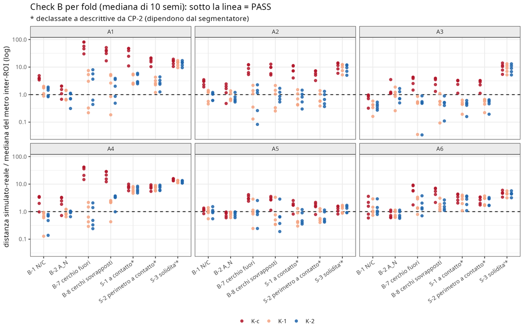

Check B per fold: distanza simulato–reale (mediana di 10 semi) divisa per la mediana del metro inter-ROI; sotto 1 = PASS.

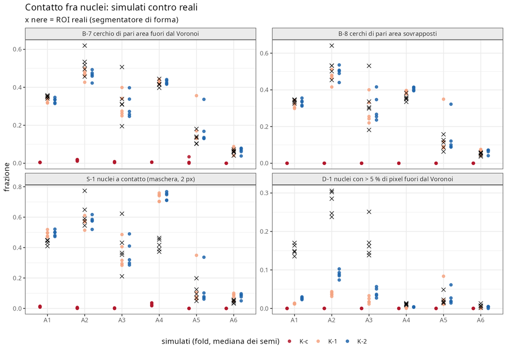

Contatto: valori simulati (un punto per fold) e reali (x, un punto per ROI).

```r
s <- aggregate(cbind(b7, b8, s1, sol_med, m2) ~ archetype + variant, ob, median)
r <- aggregate(cbind(b7, b8, s1, s3_median, m2) ~ archetype, rf, mean)
names(r) <- c("archetype", "b7 reale", "b8 reale", "s1 reale", "solidità reale", "m2 reale")
x <- merge(s, r); x[, -(1:2)] <- round(x[, -(1:2)], 3)
tb(x[order(x$archetype, match(x$variant, c("K-c", "K-1", "K-2"))), ], caption = "Valori (mediana dei fold × semi; reali: media dei 5 ROI)")
```

Valori (mediana dei fold × semi; reali: media dei 5 ROI)

| archetype | variant | b7 | b8 | s1 | sol_med | m2 | b7 reale | b8 reale | s1 reale | solidità reale | m2 reale |
| --- | --- | --- | --- | --- | --- | --- | --- | --- | --- | --- | --- |
| A1 | K-c | 0.005 | 0.000 | 0.012 | 0.962 | 0.000 | 0.351 | 0.339 | 0.436 | 0.947 | 0.153 |
| A1 | K-1 | 0.335 | 0.320 | 0.493 | 0.960 | 0.013 | 0.351 | 0.339 | 0.436 | 0.947 | 0.153 |
| A1 | K-2 | 0.331 | 0.333 | 0.496 | 0.960 | 0.026 | 0.351 | 0.339 | 0.436 | 0.947 | 0.153 |
| A2 | K-c | 0.016 | 0.000 | 0.002 | 0.968 | 0.000 | 0.525 | 0.532 | 0.626 | 0.954 | 0.276 |
| A2 | K-1 | 0.471 | 0.474 | 0.570 | 0.966 | 0.038 | 0.525 | 0.532 | 0.626 | 0.954 | 0.276 |
| A2 | K-2 | 0.466 | 0.500 | 0.577 | 0.966 | 0.088 | 0.525 | 0.532 | 0.626 | 0.954 | 0.276 |
| A3 | K-c | 0.006 | 0.000 | 0.000 | 0.969 | 0.000 | 0.332 | 0.330 | 0.397 | 0.954 | 0.173 |
| A3 | K-1 | 0.275 | 0.255 | 0.316 | 0.968 | 0.018 | 0.332 | 0.330 | 0.397 | 0.954 | 0.173 |
| A3 | K-2 | 0.273 | 0.267 | 0.320 | 0.968 | 0.037 | 0.332 | 0.330 | 0.397 | 0.954 | 0.173 |
| A4 | K-c | 0.006 | 0.000 | 0.026 | 0.963 | 0.000 | 0.418 | 0.356 | 0.419 | 0.958 | 0.011 |
| A4 | K-1 | 0.425 | 0.390 | 0.741 | 0.962 | 0.001 | 0.418 | 0.356 | 0.419 | 0.958 | 0.011 |
| A4 | K-2 | 0.424 | 0.406 | 0.748 | 0.962 | 0.004 | 0.418 | 0.356 | 0.419 | 0.958 | 0.011 |
| A5 | K-c | 0.004 | 0.000 | 0.000 | 0.976 | 0.000 | 0.132 | 0.109 | 0.107 | 0.975 | 0.024 |
| A5 | K-1 | 0.149 | 0.104 | 0.086 | 0.976 | 0.017 | 0.132 | 0.109 | 0.107 | 0.975 | 0.024 |
| A5 | K-2 | 0.145 | 0.108 | 0.086 | 0.976 | 0.023 | 0.132 | 0.109 | 0.107 | 0.975 | 0.024 |
| A6 | K-c | 0.000 | 0.000 | 0.000 | 0.966 | 0.000 | 0.059 | 0.049 | 0.045 | 0.954 | 0.007 |
| A6 | K-1 | 0.071 | 0.067 | 0.087 | 0.966 | 0.003 | 0.059 | 0.049 | 0.045 | 0.954 | 0.007 |
| A6 | K-2 | 0.069 | 0.066 | 0.085 | 0.966 | 0.004 | 0.059 | 0.049 | 0.045 | 0.954 | 0.007 |

```r
b4$trunc_all <- round(b4$trunc_all, 3); b4$loss_all <- round(b4$loss_all, 4)
tb(b4[order(b4$archetype, match(b4$variant, c("K-c", "K-1", "K-2"))), ], caption = "B-4: frazione troncata e perdita media d'area")
```

B-4: frazione troncata e perdita media d’area

| archetype | variant | trunc_all | loss_all | verdict |
| --- | --- | --- | --- | --- |
| A1 | K-c | 0.164 | 0.0461 | FAIL |
| A1 | K-1 | 0.349 | 0.0264 | FAIL |
| A1 | K-2 | 0.027 | 0.0055 | PASS |
| A2 | K-c | 0.327 | 0.1081 | FAIL |
| A2 | K-1 | 0.491 | 0.0501 | FAIL |
| A2 | K-2 | 0.047 | 0.0104 | PASS |
| A3 | K-c | 0.179 | 0.0591 | FAIL |
| A3 | K-1 | 0.325 | 0.0311 | FAIL |
| A3 | K-2 | 0.034 | 0.0085 | PASS |
| A4 | K-c | 0.478 | 0.0945 | FAIL |
| A4 | K-1 | 0.499 | 0.0205 | FAIL |
| A4 | K-2 | 0.023 | 0.0020 | PASS |
| A5 | K-c | 0.068 | 0.0218 | FAIL |
| A5 | K-1 | 0.190 | 0.0197 | FAIL |
| A5 | K-2 | 0.041 | 0.0129 | PASS |
| A6 | K-c | 0.003 | 0.0009 | PASS |
| A6 | K-1 | 0.085 | 0.0069 | FAIL |
| A6 | K-2 | 0.015 | 0.0040 | PASS |

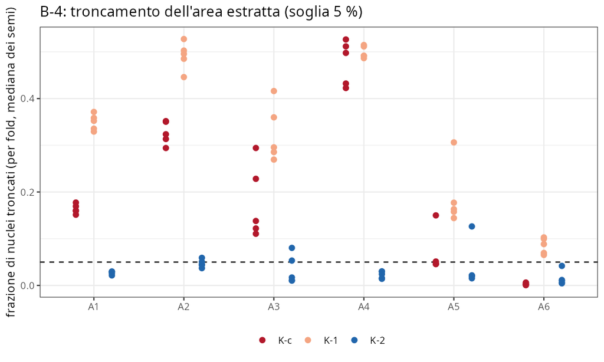

B-4 per fold.

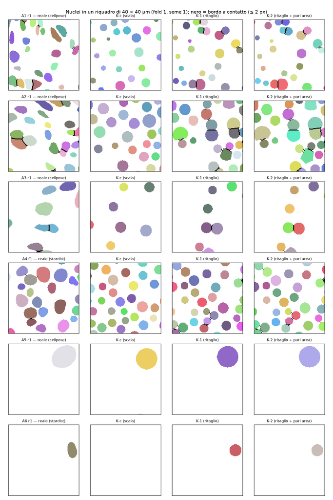

Riquadri di 40 × 40 µm: maschera reale contro K-c, K-1, K-2 (fold 1, seme 1); nero = bordo a contatto.

**Lettura.**

- **K-c non produce contatti**: B-7 ≈ 0.005, B-8 = 0 e S-1 ≈ 0.01 in tutti gli archetipi, contro valori reali da 0.05 (A6) a 0.6 (A2). K-1 e K-2 portano B-7 e B-8 vicino ai reali ovunque.
- **A1 resta FAIL**: i 5 ROI di A1 sono molto omogenei (mediana del metro di B-7 0.006), quindi anche uno scarto di 0.02 su 0.35 fallisce.
- **K-2 elimina il troncamento**: 1.5–4.7 % contro 16–48 % di K-c in A1–A4. Migliora anche B-1/B-2 in A2, A4 e A6.
- **Discrepanze che restano con ogni variante**:
  - D-1: i nuclei reali sconfinano oltre il Voronoi dei centroidi molto più dei simulati (m2 0.15–0.28 contro 0.03–0.09 in A1–A3). La faccia di contatto reale non cade sulla bisettrice, il che rimanda a Laguerre (BL-117).
  - I nuclei simulati sono più convessi (solidità 0.960–0.976 contro 0.947–0.975) e circolari, mentre i reali sono allungati.
  - In A4 S-1 simulato vale 0.75 contro 0.42, perché i simulati stanno sui generatori Space Ranger (circa il 40 % in più dei nuclei StarDist che fanno da vicini reali).

```r
tb(aggregate(cbind(q99, phi) ~ archetype, phi, function(z) round(median(z), 3)), caption = "Tetto di K-2: q99 di N/C reale dei ROI di addestramento (mediana dei 5 fold)")
```

Tetto di K-2: q99 di N/C reale dei ROI di addestramento (mediana dei 5 fold)

| archetype | q99 | phi |
| --- | --- | --- |
| A1 | 0.757 | 0.757 |
| A2 | 1.054 | 1.000 |
| A3 | 0.951 | 0.951 |
| A4 | 0.816 | 0.816 |
| A5 | 0.484 | 0.484 |
| A6 | 0.182 | 0.182 |

# 4. Controprova

**CP-0 (premessa di BL-098 riformulata, senza modello).** Sulle coppie di Delaunay dei nuclei reali, la sovrapposizione dei cerchi di pari area predice il contatto in maschera con AUC 0.95–0.97 in A1–A4: **premessa non smentita**.

```r
cp0$auc <- round(cp0$auc, 3); cp0$frac_contact <- round(cp0$frac_contact, 3); tb(cp0)
```

| archetype | n_pairs | frac_contact | auc | auc_ok |
| --- | --- | --- | --- | --- |
| A1 | 104883 | 0.097 | 0.960 | TRUE |
| A2 | 92478 | 0.177 | 0.947 | TRUE |
| A3 | 61331 | 0.110 | 0.967 | TRUE |
| A4 | 301695 | 0.085 | 0.974 | TRUE |
| A5 | 7020 | 0.020 | 0.994 | TRUE |
| A6 | 8552 | 0.008 | 0.997 | TRUE |

**CP-1 (controllo negativo).**

```r
tb(cp1)
```

| gain_A1_A4 | gain_per_pair_A1_A4 | gain_A5_A6 | refuted | gain_A1_A4_panel | gain_A5_A6_panel |
| --- | --- | --- | --- | --- | --- |
| 6 | 3 | 3 | TRUE | 4 | 1 |

**Smentita, al limite.** Sulle 7 metriche il guadagno in A5 + A6 (3 PASS) è uguale al guadagno medio per coppia in A1–A4 (6/2 = 3), e la regola pre-registrata usa «≥». Sul pannello della decisione è 1 contro 4/2 = 2.

Il guadagno dipende dal fatto che K-c non ammette alcun contatto, e questo vale anche nei tessuti radi, dove i contatti reali sono il 5–11 %. Il miglioramento di K-2 è quindi **generale** (ammettere il contatto) e non legato alla densità. Come prova di una deformazione legata alla densità, la controprova non regge.

**CP-2 (robustezza dei riferimenti al segmentatore).**

```r
tb(cp2[, c("metric", "archetype", "primary", "d_seg", "yard_max", "n_roi_above", "exceeds", "primary_value", "other_value")])
```

| metric | archetype | primary | d_seg | yard_max | n_roi_above | exceeds | primary_value | other_value |
| --- | --- | --- | --- | --- | --- | --- | --- | --- |
| S1 | A1 | cellpose_rgb | 0.145;0.168;0.188;0.184;0.185 | 0.0206;0.0392;0.033;0.0339;0.0392 | 5 | TRUE | 0.419;0.4;0.433;0.434;0.439 | 0.274;0.232;0.245;0.25;0.254 |
| S1 | A2 | cellpose_rgb | 0.294;0.261;0.265;0.355;0.299 | 0.198;0.228;0.186;0.228;0.127 | 5 | TRUE | 0.565;0.535;0.577;0.762;0.635 | 0.271;0.273;0.311;0.408;0.336 |
| S1 | A3 | cellpose_rgb | 0.134;0.0651;0.164;0.153;0.296 | 0.269;0.406;0.257;0.216;0.406 | 0 | FALSE | 0.344;0.207;0.356;0.423;0.613 | 0.21;0.142;0.192;0.269;0.316 |
| S1 | A4 | stardist_he | 0.000392;0.0888;0.0562;0.0848;0.127 | 0.0899;0.0471;0.0727;0.0785;0.0899 | 3 | TRUE | 0.371;0.414;0.389;0.45;0.461 | 0.371;0.325;0.332;0.365;0.335 |
| S1 | A5 | cellpose_rgb | 0.095;0.00407;0.0177;0.00799;0.0199 | 0.155;0.135;0.155;0.115;0.0965 | 0 | FALSE | 0.203;0.0676;0.0474;0.0874;0.106 | 0.108;0.0717;0.0651;0.0954;0.0863 |
| S1 | A6 | stardist_he | 0.0363;0.0396;0.0956;0.00365;0.0308 | 0.0296;0.0207;0.0256;0.0296;0.027 | 4 | TRUE | 0.074;0.0533;0.07;0.0444;0.0714 | 0.0377;0.0137;0.166;0.0407;0.0407 |
| S2 | A1 | cellpose_rgb | 0.174;0.188;0.22;0.218;0.194 | 0.0287;0.0416;0.0386;0.0416;0.0395 | 5 | TRUE | 0;0;0;0;0 | 0;0;0;0;0 |
| S2 | A2 | cellpose_rgb | 0.31;0.292;0.294;0.454;0.372 | 0.24;0.254;0.229;0.254;0.137 | 5 | TRUE | 0.08;0.0526;0.0938;0.242;0.167 | 0;0;0;0;0 |
| S2 | A3 | cellpose_rgb | 0.146;0.0741;0.186;0.173;0.355 | 0.285;0.407;0.259;0.216;0.407 | 0 | FALSE | 0;0;0;0;0.168 | 0;0;0;0;0 |
| S2 | A4 | stardist_he | 0.0931;0.0889;0.0811;0.085;0.127 | 0.093;0.0491;0.0729;0.0811;0.093 | 5 | TRUE | 0;0;0;0;0 | 0;0;0;0;0 |
| S2 | A5 | cellpose_rgb | 0.108;0.0097;0.0177;0.0138;0.0286 | 0.155;0.137;0.155;0.12;0.102 | 0 | FALSE | 0;0;0;0;0 | 0;0;0;0;0 |
| S2 | A6 | stardist_he | 0.0363;0.0396;0.0956;0.0131;0.0308 | 0.0296;0.0224;0.0273;0.0298;0.0298 | 4 | TRUE | 0;0;0;0;0 | 0;0;0;0;0 |
| S3 | A1 | cellpose_rgb | 0.205;0.216;0.226;0.241;0.241 | 0.0385;0.0356;0.0418;0.0418;0.0363 | 5 | TRUE | 0.947;0.947;0.947;0.946;0.946 | 0.955;0.954;0.955;0.954;0.955 |
| S3 | A2 | cellpose_rgb | 0.231;0.229;0.216;0.311;0.259 | 0.0844;0.0735;0.0714;0.0647;0.0844 | 5 | TRUE | 0.953;0.953;0.953;0.955;0.955 | 0.96;0.96;0.96;0.963;0.963 |
| S3 | A3 | cellpose_rgb | 0.209;0.249;0.199;0.173;0.273 | 0.108;0.155;0.109;0.155;0.117 | 5 | TRUE | 0.954;0.95;0.955;0.956;0.954 | 0.961;0.958;0.961;0.961;0.962 |
| S3 | A4 | stardist_he | 0.101;0.0944;0.0878;0.105;0.0949 | 0.0145;0.0155;0.0139;0.0155;0.0124 | 5 | TRUE | 0.959;0.959;0.958;0.958;0.958 | 0.956;0.957;0.956;0.956;0.956 |
| S3 | A5 | cellpose_rgb | 0.132;0.276;0.282;0.27;0.233 | 0.249;0.24;0.249;0.228;0.16 | 4 | TRUE | 0.971;0.977;0.977;0.977;0.976 | 0.97;0.972;0.97;0.968;0.971 |
| S3 | A6 | stardist_he | 0.208;0.193;0.153;0.131;0.19 | 0.103;0.087;0.0667;0.103;0.1 | 5 | TRUE | 0.953;0.954;0.953;0.954;0.954 | 0.942;0.943;0.948;0.949;0.946 |

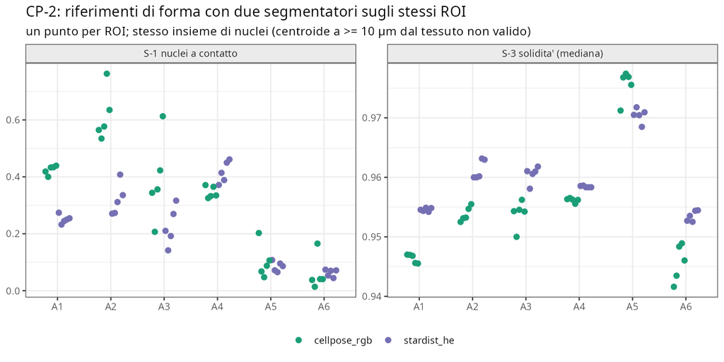

CP-2: S-1 e solidità con cellpose e StarDist sugli stessi ROI.

In A1–A3 la frequenza di contatto reale cambia di 1.5–2× fra i due segmentatori. Per regola, S-1, S-2 e S-3 sono diventate descrittive. **I riferimenti di forma a livello di maschera non sono un bersaglio affidabile** finché non c’è una verità di riferimento (BL-024 / R2b).

## Previsioni

```r
tb(pr[, c("id", "text", "observed", "confirmed")])
```

| id | text | observed | confirmed |
| --- | --- | --- | --- |
| P1 | S-1 reale >= 0.30 in A1-A4 e <= 0.15 in A5, A6 | A1 0.436; A2 0.626; A3 0.397; A4 0.419; A5 0.107; A6 0.045 | TRUE |
| P2 | B-4 di K-2 <= 0.05 in >= 4/6 | A1 0.027; A2 0.047; A3 0.034; A4 0.023; A5 0.041; A6 0.015 | TRUE |
| P3 | K-1: B-2 FAIL in A1-A4 | A1 WARN; A2 WARN; A3 WARN; A4 WARN | FALSE |
| P4 | punteggio(K-2) >= punteggio(K-c) + 3 | K-2 8, K-c 3 | TRUE |
| P5 | solidita’ reale mediana >= 0.95, entrambi i segmentatori, 6/6 | A1/ce 0.946; A1/st 0.955; A2/ce 0.954; A2/st 0.961; A3/ce 0.954; A3/st 0.961; A4/ce 0.956; A4/st 0.958; A5/ce 0.975; A5/st 0.971; A6/ce 0.946; A6/st 0.953 | FALSE |
| P6 | CP-0 AUC >= 0.75 in A1-A4 | A1 0.960; A2 0.947; A3 0.967; A4 0.974; A5 0.994; A6 0.997 | TRUE |

## Decisione

```r
tb(dc[, c("variant", "eligible", "score", "score_Kc", "margin_ok", "p_boot", "p_ok", "wins", "choice")])
```

| variant | eligible | score | score_Kc | margin_ok | p_boot | p_ok | wins | choice |
| --- | --- | --- | --- | --- | --- | --- | --- | --- |
| K-1 | TRUE | 7 | 3 | TRUE | 1 | TRUE | TRUE | K-2 |
| K-2 | TRUE | 8 | 3 | TRUE | 1 | TRUE | TRUE | K-2 |

```r
tb(data.frame(variante = names(bs), media = round(colMeans(bs), 2), min = apply(bs, 2, min), max = apply(bs, 2, max)), caption = "Bootstrap sui semi (200 repliche, appaiato)")
```

Bootstrap sui semi (200 repliche, appaiato)

| variante | media | min | max |
| --- | --- | --- | --- |
| K-1 | 6.90 | 5 | 8 |
| K-2 | 8.36 | 7 | 11 |
| K-c | 2.60 | 2 | 3 |

Per regola: **K-2**. K-2 resta **contenuto** nel territorio (C3 = 0), quindi design §7.2 e lo Step 2 non cambiano.

# Verdetto

[output not shown]

# Revisione avversariale

| id | revisore | tipo | rilievo | cambia verdetto o decisione |
| --- | --- | --- | --- | --- |
| RC-01 | ricalcolo | conferma | Verdetti di fold (630) e d’archetipo (126) per K-c/K-1/K-2 x B1,B2,B7,B8,S1,S2,S3 riprodotti con codice Python proprio da obs/*.rds e metri ricostruiti (B1/B2 da yard loo S1.4, B7/B8 da prep, S1-S3 da… | no |
| RC-02 | ricalcolo | conferma | Distanze per seme ri-derivate da zero dai grezzi sim_out con un Voronoi proprio (shapely + regola orfani D-S1.3.2 ricodificata), B-8 con cKDTree, KS di scipy. | no |
| RC-03 | ricalcolo | conferma | CP-2: declassazione di S1 (4/6), S2 (4/6), S3 (6/6) riprodotta dai parquet cp2; pannello B1,B2,B7,B8. Robusta: in S1 resta >=3/6 anche se A4 (3/5 ROI, il caso al limite) cambiasse. | no |
| RC-04 | ricalcolo | conferma | Punteggi K-c 3, K-1 7, K-2 8 (pannello); su 7 metriche 3/10/12. Bootstrap indipendente (numpy, semi 777 e 31415): P(K-1>K-c)=P(K-2>K-c)=1.0; scelta K-2 con la regola pre-registrata. | no |
| RC-05 | ricalcolo | rilievo | La scelta K-2 rispetto a K-1 poggia su una sola cella del pannello: A2 x B2 (K-2 PASS 4/5, K-1 WARN 3/5). L’altra differenza (A6 x B7: K-1 WARN, K-2 FAIL) non sposta il punteggio. La regola 4 non chie… | no |
| RC-06 | ricalcolo | conferma | B-4 per archetipo e variante (media sui fold della mediana sui semi di trunc_all) riprodotto; K-2 PASS 6/6. | no |
| RC-07 | ricalcolo | rilievo | B-4 di K-2: A2 a 0.003 dalla soglia (0.0470) e 5 fold singoli oltre 0.05; il PASS 6/6 dipende dall’aggregazione ‘media sui fold’ delle dev notes. | no |
| RC-08 | ricalcolo | conferma | S-1 reale ricalcolato su tutti i 30 ROI dalle maschere native con un metodo diverso (ciclo per etichetta su bounding box + dilatazione binaria 5x5), con l’appaiamento A4/A6 (BL-060) rifatto in shapely… | no |
| RC-09 | ricalcolo | conferma | CP-0 AUC ricalcolata con Delaunay di scipy e coppie di contatto proprie, su tutti i 30 ROI e riunita per archetipo. | no |
| RC-10 | ricalcolo | rilievo | Lo score di CP-0 nel codice è (r_i+r_j)/d_ij (dichiarato nelle dev notes prima del run); la pre-registrazione scrive r_i+r_j-d_ij. Le due non sono monotone l’una dell’altra. Con lo score pre-registrat… | no |
| RC-11 | ricalcolo | conferma | CP-1: guadagno K-2 su K-c 6 in A1-A4 (3 per coppia) e 3 in A5+A6 -> smentita, come riportato. | no |
| RC-12 | ricalcolo | rilievo | CP-1 è smentita all’uguaglianza (3 >= 3); sul pannello effettivo (dopo CP-2) sarebbe 1 < 2, cioè non smentita: 2 dei 3 punti di guadagno in A5+A6 vengono da metriche S poi declassate. Con le 7 metrich… | no |
| RC-13 | ricalcolo | conferma | Raster indipendente (shapely.contains_xy sui centri dei pixel) di 6 file gen_in (A1 r1 e A4 f1, fold 1, s01, K-c/K-1/K-2): n_px identico per ogni nucleo, centroidi, n_bnd, n_c2 e S-1 ev identici, 0 co… | no |
| RC-14 | ricalcolo | conferma | C-0: K-c con derive_cell_geometry (random_seed = seed + 100000*s, s=0..10) su 4 fold (A1:1, A2:2, A4:3, A6:5) riproduce V-c di S1.4b con metriche ricalcolate da me. | no |
| RC-15 | ricalcolo | rilievo | Sensibilità alla regola dei frammenti di Voronoi: senza riassegnazione degli orfani B1 cambia in 57/900 osservazioni (max 4.5e-3); cambiano 1 verdetto di fold e 1 d’archetipo, ma non i punteggi. Un er… | no |
| RC-16 | ricalcolo | rilievo | Fragilità locale: A6xB2 è PASS per tutte le varianti grazie al fold 3 con d/mediana 0.991-0.998 (un eventuale cambio toglierebbe 1 punto a tutte, senza cambiare le differenze); A4xB2 K-2 ha il fold 5 … | no |
| RC-17 | ricalcolo | rilievo | S-2 è quasi ridondante con S-1: la mediana reale di S-2 è 0 in 24/30 ROI, quindi la KS è dominata dalla massa in 0; in CP-2 A6 d_seg di S1 e S2 coincide in 4/5 ROI. Nessun effetto sulla decisione (ent… | no |
| RC-18 | ricalcolo | rilievo | Con K-1/K-2 il contatto simulato supera di molto quello reale: K-2 vince sulle metriche B, non sulla forma del contatto. | no |
| RC-19 | ricalcolo | conferma | phi di K-2 (q99 tipo 7 di a_n/a_t sull’insieme ev dei 4 ROI di addestramento) riprodotto per tutti i 30 fold; insieme ev = interior & matched & a_n>0 identico al prep in 30/30 ROI. | no |
| RC-20 | ricalcolo | conferma | Correzione D-6 (eleggibilità): con ‘C-perf solo WARN’ della pre-registrazione, K-2 è eleggibile (tutti gli altri check C di K-2 PASS in checks.csv) e la scelta corretta è K-2. Va comunque notato che l… | no |
| CODE-1 | codice | conferma | Stadio obs ricalcolato in modo indipendente (Voronoi shapely, cerchi cKDTree, KS propria) su 900/900 file. | no |
| CODE-2 | codice | conferma | Allineamento dei metri e assenza di fuga dal ROI di test. | no |
| CODE-3 | codice | conferma | K-1/K-2: vuoti, buchi, tetto, multiparte, K-1 contenuto in K-2 dove il tetto non e’ attivo. | no |
| CODE-4 | codice | conferma | La fessura di 2e-5 um (rientro 1e-5) non cambia in modo rilevante contatto raster, solidita’ o area. | no |
| CODE-5 | codice | conferma | Operatore raster: regola del centro del pixel, bordo, contatto con sentinella, coppie di contatto. | no |
| CODE-6 | codice | rilievo | Solidita’ di skimage su oggetti piccoli: distorta e dipendente dalla taglia; a ~200 px non distingue una forma da un disco. Etichette reali sconnesse asimmetriche. | no |
| CODE-7 | codice | rilievo | Asimmetrie A4/A6 (simulati sui generatori SR, vicini reali StarDist, B-8 con a_own, B-7 sul generatore SR) quantificate. | no |
| CODE-8 | codice | discrepanza | CP-0: score (r_i+r_j)/d_ij nel codice contro r_i+r_j-d_ij nella pre-registrazione. | no |
| CODE-9 | codice | rilievo | D-6 (C-perf escluso dall’eleggibilita’): coerente con «C-perf solo WARN», ma fatta dopo i risultati e capovolge la scelta. | sì |
| CODE-10 | codice | rilievo | K-2 batte K-1 di un solo punto (A2 x B-2, 4/5 contro 3/5 fold PASS); la regola 4 non ha criterio bootstrap fra K-1 e K-2. | no |
| CODE-11 | codice | rilievo | CP-1 smentita come pre-registrata (7 metriche) ma non sul pannello dopo CP-2; nessuna conseguenza fissata dalla pre-registrazione. | no |
| CODE-12 | codice | conferma | CP-2 ricalcolata; declassamento di S-1, S-2, S-3 robusto a due regole alternative. | no |
| CODE-13 | codice | rilievo | I test di decisione non coprono bootstrap e metro: 3/10 mutanti costruiti non rilevati. | no |
| CODE-14 | codice | conferma | Mutanti C-mut rilevati per il motivo giusto; MU5 ha effetto grande nel banco. | no |
| CODE-15 | codice | conferma | Strato di decisione ricalcolato con codice proprio; robustezza descrittiva. | no |

[output not shown]

# Riproducibilità

Commit: vedi `git log` (pre-registrazione `c41cf8b`, codice `e76cb6d`, risultati `d710cfb`). Comandi dalla root del repo:

```bash
bash tools/run_S1.4c.sh            # test, prep, real, cp2, gen, sim, obs, mut, perf; grezzi in /mnt/micron/geo_spatialtrans/S1.4c/
R_LIBS_SITE=/nonexistent R_LIBS_USER=/nonexistent Rscript --vanilla tools/S1.4c_analysis.R
R_LIBS_SITE=/nonexistent R_LIBS_USER=/nonexistent Rscript --vanilla tools/S1.4c_figures.R && .venv/bin/python tools/S1.4c_fig_maps.py
quarto render reports/S1.4c.qmd
```